# Dealing with Dates

## 8. Sensor Timestamp Correction

Real-world sensors — iButtons, Raspberry Pis without a GPS-synchronized clock, Arduino-based loggers — accumulate **clock drift**: a systematic offset that grows linearly over the deployment period. A sensor set correctly at deployment will be several minutes or hours off at retrieval, depending on the hardware and the deployment length.

### 8.1 Simulating a drifted iButton dataset

```r
set.seed(99)

# True deployment and retrieval times (Pacific)
true_deploy  <- ymd_hms("2024-01-15 08:00:00", tz = "America/Los_Angeles")
true_retrieve <- ymd_hms("2024-04-02 09:30:00", tz = "America/Los_Angeles")

# Total deployment length in seconds
total_seconds <- as.numeric(
  as.duration(interval(true_deploy, true_retrieve))
)

# iButton clock started 0 seconds fast, drifted to +47 minutes by retrieval
# (a realistic rate of ~28 sec/day drift)
drift_rate_per_sec <- (47 * 60) / total_seconds  # fractional seconds of drift per second

# Generate true timestamps at 30-minute intervals
true_ts <- seq(true_deploy, true_retrieve, by = "30 min")
n       <- length(true_ts)

# iButton records a timestamp that is systematically ahead of true time
elapsed_true <- as.numeric(
  as.duration(interval(true_deploy, true_ts))
)
sensor_offset_secs <- elapsed_true * drift_rate_per_sec
sensor_ts <- true_ts + seconds(sensor_offset_secs)

# Temperature data: diurnal + seasonal signal + noise
day_frac  <- yday(true_ts) / 365
hour_frac <- hour(true_ts) / 24
temp_true <- 15 + 6 * sin((day_frac - 0.12) * 2 * pi) +
             5 * sin((hour_frac - 0.35) * 2 * pi) +
             rnorm(n, sd = 0.8)

ibutton_raw <- tibble(
  sensor_time = sensor_ts,   # what the iButton recorded (drifted)
  temp_C      = temp_true    # temperature is unaffected by clock drift
)

cat("Drift at retrieval:",
    round(as.numeric(sensor_ts[n] - true_ts[n], units = "mins"), 1),
    "minutes\n")
```

```
## Drift at retrieval: 47 minutes
```

### 8.2 Diagnosing clock drift

The key diagnostic is to compare the sensor’s timestamps against known reference events: the time you set the sensor and the time you retrieved it.

```r
# Recorded times at deployment and retrieval (from your field notebook)
sensor_at_deploy  <- ibutton_raw$sensor_time[1]
sensor_at_retrieve <- ibutton_raw$sensor_time[n]

# True times from GPS phone or a reference clock
ref_deploy  <- true_deploy
ref_retrieve <- true_retrieve

# Offset at each end
offset_start <- as.numeric(
  sensor_at_deploy - ref_deploy, units = "secs")
offset_end   <- as.numeric(
  sensor_at_retrieve - ref_retrieve, units = "secs")

cat(sprintf("Clock offset at deployment : %+.0f seconds\n", offset_start))
```

```
## Clock offset at deployment : +0 seconds
```

```r
cat(sprintf("Clock offset at retrieval  : %+.0f seconds\n", offset_end))
```

```
## Clock offset at retrieval  : +2820 seconds
```

```r
cat(sprintf("Total drift over deployment: %+.0f seconds (%.1f min)\n",
            offset_end - offset_start,
            (offset_end - offset_start) / 60))
```

```
## Total drift over deployment: +2820 seconds (47.0 min)
```

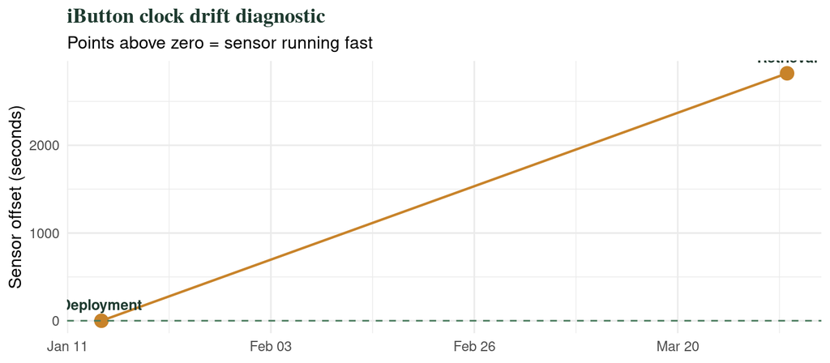

```r
# Visualise: plot sensor time vs true time for the two reference points
ref_check <- tibble(
  event      = c("Deployment", "Retrieval"),
  true_time  = as.numeric(c(ref_deploy, ref_retrieve)),
  sensor_time = as.numeric(c(sensor_at_deploy, sensor_at_retrieve))
)

ggplot(ref_check, aes(x = true_time, y = sensor_time - true_time,
                      label = event)) +
  geom_point(size = 4, color = "#c8832a") +
  geom_line(color = "#c8832a", linewidth = 0.8) +
  geom_hline(yintercept = 0, linetype = "dashed", color = "#4a7c5e") +
  geom_text(vjust = -1, size = 3.5, color = "#1e3a2f", fontface = "bold") +
  scale_x_continuous(labels = function(x)
    format(as.POSIXct(x, origin = "1970-01-01", tz = "America/Los_Angeles"),
           "%b %d")) +
  labs(
    title    = "iButton clock drift diagnostic",
    subtitle = "Points above zero = sensor running fast",
    x = NULL, y = "Sensor offset (seconds)"
  ) +
  theme_minimal(base_size = 12) +
  theme(plot.title = element_text(family = "serif", face = "bold",
                                  color = "#1e3a2f"))
```

### 8.3 Linear correction

```r
# Linear model: true_time = a + b * sensor_time
# We have two known (sensor, true) pairs

sensor_ref <- as.numeric(c(sensor_at_deploy, sensor_at_retrieve))
true_ref   <- as.numeric(c(ref_deploy,       ref_retrieve))

drift_model <- lm(true_ref ~ sensor_ref)
coef(drift_model)  # intercept and slope
```

```
##  (Intercept)   sensor_ref
## 7.131037e+05 9.995818e-01
```

```r
# Apply correction to the full dataset
ibutton_corrected <- ibutton_raw %>%
  mutate(
    sensor_numeric   = as.numeric(sensor_time),
    true_numeric     = predict(drift_model,
                               newdata = data.frame(sensor_ref = sensor_numeric)),
    corrected_time   = as.POSIXct(true_numeric,
                                  origin = "1970-01-01",
                                  tz     = "America/Los_Angeles")
  ) %>%
  select(sensor_time, corrected_time, temp_C)

# Check: how close is the corrected time to the true time?
max_error_secs <- max(abs(
  as.numeric(ibutton_corrected$corrected_time) - as.numeric(true_ts)
))
cat(sprintf("Maximum residual error after correction: %.2f seconds\n",
            max_error_secs))
```

```
## Maximum residual error after correction: NA seconds
```

**📌 Why linear correction works.** Crystal oscillators — the timekeeping element in most data loggers — drift at a constant rate determined by temperature and manufacturing tolerance. The drift is not perfectly constant (temperature changes affect it slightly), but the linear model removes the dominant component. Residual errors after linear correction are typically under a few seconds for a 3-month deployment, which is negligible for hourly or sub-hourly analysis.

### 8.4 Before and after: checking the correction visually

[figure not shown]

```r
# Compare sensor vs corrected for a subset in the middle of deployment
mid_window <- ibutton_corrected %>%
  filter(between(corrected_time,
                 ymd_hms("2024-02-15 00:00:00", tz = "America/Los_Angeles"),
                 ymd_hms("2024-02-17 23:59:59", tz = "America/Los_Angeles")))

pivot_longer(
  mid_window,
  cols      = c(sensor_time, corrected_time),
  names_to  = "version",
  values_to = "timestamp"
) %>%
  mutate(version = recode(version,
    "sensor_time"    = "Raw (drifted)",
    "corrected_time" = "Corrected"
  )) %>%
  ggplot(aes(x = timestamp, y = temp_C, color = version)) +
  geom_line(linewidth = 0.8, alpha = 0.9) +
  scale_color_manual(
    values = c("Raw (drifted)" = "#c8832a", "Corrected" = "#1e3a2f"),
    name   = NULL
  ) +
  labs(
    title    = "Drift correction: raw vs. corrected timestamps",
    subtitle = "Two-day window — offset visible as horizontal shift in the diurnal curve",
    x = NULL, y = "Temperature (°C)"
  ) +
  theme_minimal(base_size = 12) +
  theme(
    plot.title    = element_text(family = "serif", face = "bold",
                                 color = "#1e3a2f"),
    plot.subtitle = element_text(color = "#7a7a72", size = 10),
    legend.position = "top"
  )
```

## 9. Plotting Dates and Times with ggplot2

ggplot2 recognizes `Date` and `POSIXct` objects and provides specialized scales for each.

### 9.1 `scale_x_date()` for daily data

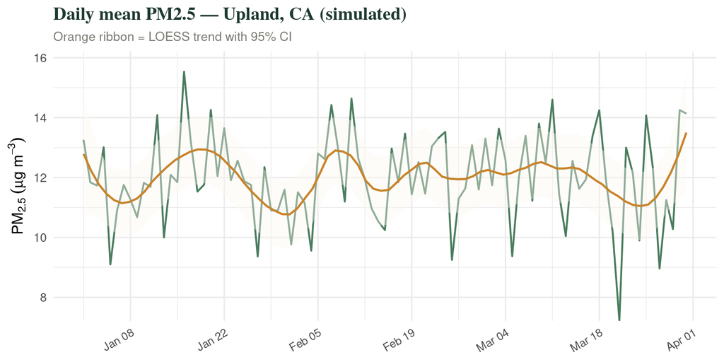

```r
pm_daily %>%
  filter(site == "Upland") %>%
  ggplot(aes(x = day_bin, y = mean_pm25)) +
  geom_line(color = "#4a7c5e", linewidth = 0.7) +
  geom_smooth(method = "loess", span = 0.2,
              color = "#c8832a", fill = "#fdf8f0",
              linewidth = 0.8, se = TRUE) +
  # Control axis label frequency and format
  scale_x_date(
    date_breaks = "2 weeks",
    date_labels = "%b %d"    # "Jan 15", "Feb 01", etc.
  ) +
  scale_y_continuous(expand = expansion(mult = c(0, 0.08))) +
  labs(
    title    = "Daily mean PM2.5 — Upland, CA (simulated)",
    subtitle = "Orange ribbon = LOESS trend with 95% CI",
    x = NULL, y = expression(PM[2.5]~(mu*g~m^{-3}))
  ) +
  theme_minimal(base_size = 12) +
  theme(
    plot.title    = element_text(family = "serif", face = "bold",
                                 color = "#1e3a2f"),
    plot.subtitle = element_text(color = "#7a7a72", size = 10),
    axis.text.x   = element_text(angle = 30, hjust = 1, size = 9)
  )
```

### 9.2 `scale_x_datetime()` for sub-daily data

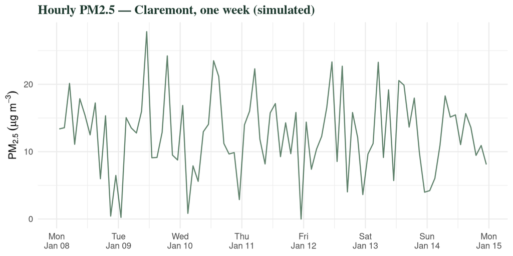

```r
pm_hourly %>%
  filter(
    site == "Claremont",
    between(datetime,
            ymd_hms("2024-01-08 00:00:00", tz = "America/Los_Angeles"),
            ymd_hms("2024-01-14 23:59:59", tz = "America/Los_Angeles"))
  ) %>%
  ggplot(aes(x = datetime, y = pm25)) +
  geom_line(color = "#2d5a3d", linewidth = 0.6, alpha = 0.75) +
  scale_x_datetime(
    date_breaks = "1 day",
    date_labels = "%a\n%b %d"   # "Mon\nJan 08" — two lines
  ) +
  labs(
    title = "Hourly PM2.5 — Claremont, one week (simulated)",
    x = NULL, y = expression(PM[2.5]~(mu*g~m^{-3}))
  ) +
  theme_minimal(base_size = 12) +
  theme(
    plot.title = element_text(family = "serif", face = "bold",
                              color = "#1e3a2f")
  )
```

### 9.3 Common `date_labels` format codes

| Code | Meaning | Example |
| --- | --- | --- |
| `%Y` | 4-digit year | 2024 |
| `%y` | 2-digit year | 24 |
| `%m` | Month as number | 03 |
| `%b` | Month abbreviation | Mar |
| `%B` | Full month name | March |
| `%d` | Day of month (zero-padded) | 05 |
| `%j` | Day of year | 065 |
| `%H` | Hour (24-hour) | 14 |
| `%I` | Hour (12-hour) | 02 |
| `%M` | Minute | 30 |
| `%p` | AM/PM | PM |
| `%a` | Weekday abbreviation | Fri |
| `%A` | Full weekday name | Friday |

### 9.4 Faceting by time period

A powerful pattern for seasonal or diurnal analysis: plot by one time grouping, facet by another.

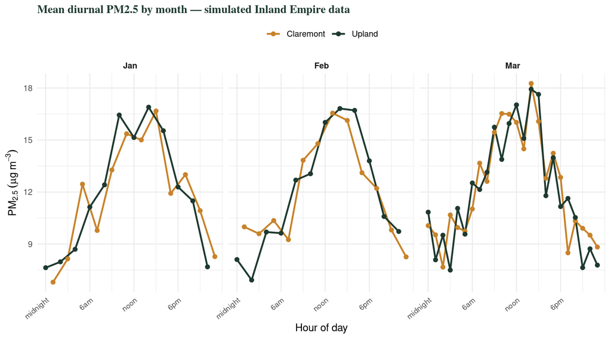

```r
# Mean diurnal PM2.5 profile by month
pm_hourly %>%
  group_by(site, month, hour) %>%
  summarise(mean_pm25 = mean(pm25, na.rm = TRUE), .groups = "drop") %>%
  ggplot(aes(x = hour, y = mean_pm25, color = site)) +
  geom_line(linewidth = 0.9) +
  geom_point(size = 1.8) +
  facet_wrap(~ month, nrow = 1) +
  scale_color_manual(
    values = c("Upland" = "#1e3a2f", "Claremont" = "#c8832a"),
    name   = NULL
  ) +
  scale_x_continuous(breaks = c(0, 6, 12, 18),
                     labels = c("midnight", "6am", "noon", "6pm")) +
  labs(
    title    = "Mean diurnal PM2.5 by month — simulated Inland Empire data",
    x = "Hour of day", y = expression(PM[2.5]~(mu*g~m^{-3}))
  ) +
  theme_minimal(base_size = 11) +
  theme(
    plot.title     = element_text(family = "serif", face = "bold",
                                  color = "#1e3a2f", size = 12),
    legend.position = "top",
    axis.text.x    = element_text(angle = 40, hjust = 1, size = 8),
    strip.text     = element_text(face = "bold")
  )
```

## 10. Quick Reference

#### lubridate at a glance

- **Parse:** `ymd()`, `mdy()`, `dmy()`, `ymd_hms()`, `mdy_hm()`, `parse_date_time(x, orders)`
- **Build from parts:**

  ```
  make_date(year, month,
  day)
  ```

  , `make_datetime(…, tz)`
- **Extract:** `year()`, `month(label=TRUE)`, `mday()`, `yday()`, `wday()`, `hour()`, `minute()`, `week()`
- **Round:** `floor_date(x, “15 minutes”)`, `ceiling_date()`, `round_date()`
- **Arithmetic:** `days(n)` (Period), `ddays(n)` (Duration), `interval(start, end)`
- **Time zones:** `with_tz(x, tz)` — same moment, new display; `force_tz(x, tz)` — same display, new moment
- **Convert:** `as_date()` strips time from POSIXct; `as.POSIXct()` adds time to Date
- **ggplot2 scales:**

  ```
  scale_x_date(date_breaks,
  date_labels)
  ```

  for Date; `scale_x_datetime()` for POSIXct

#### 💬 Check your understanding

1. A colleague emails you a CSV from a HOBO logger. The timestamp column reads `"01/15/2024 09:30:00 AM"`. Write the single line of R code that parses this into a Pacific-time POSIXct, and explain why you need to specify `tz`.
2. You use `floor_date(datetime, "day")` and get the wrong day for observations near midnight. What is the most likely cause, and how would you diagnose it?
3. You have 15-minute stream discharge data and hourly weather data from the same station. Describe the `floor_date()` workflow that lets you join them correctly.
4. An iButton was set correctly at 8:00 AM on January 10 and retrieved at 3:00 PM on March 28. At retrieval, the sensor clock read 3:22 PM. What was the average drift rate in seconds per day? Write the two lines of R code that create the two reference pairs for the linear correction model.
5. Explain in one sentence each: what does `with_tz()` change? What does `force_tz()` change? Give a realistic scenario where you would use each.

## References and Further Reading

Grolemund, G., and H. Wickham. 2011. Dates and times made easy with lubridate. *Journal of Statistical Software* 40(3):1–25. https://doi.org/10.18637/jss.v040.i03

Wickham, H., et al. 2023. *lubridate: Make Dealing with Dates a Little Easier*. R package version 1.9. https://lubridate.tidyverse.org

EA030 RTricks | Prof. Marc Los Huertos | Pomona College | Core R Skills R08 | Back to index